# This Means (Bayesian) War(fare)!

A Bayesian Neural Network Approach to Electronic Warfare

Margaret Morrison and Joshua DiLena (Advisor: Dr. Cohen)

November 15, 2026

## 1. Operational Motivation: The EW Battleground

- Background and Motivation
- Dataset: RadioML 2018.01A
- Research Objective
- **Electronic Warfare (EW)** has been part of military operations since World War I, evolving alongside communications technology
  - Protects aircraft and pilots in contested environments
  - Jamming can disrupt communications and operational effectiveness ([Electronic Warfare, n.d.](https://jdilena1999.github.io/IDC6940_BayesianNeuralNetworks/#ref-noauthor_under_nodate))
- **Modern military drones** increasingly depend on reliable radio-frequency (RF) links
  - Vulnerable to jamming and signal interference ([vgi_admin, 2025](https://jdilena1999.github.io/IDC6940_BayesianNeuralNetworks/#ref-vgi_admin_drones_2025))
- **Machine learning applications in wireless security**
  - Jere et al. (2024) combined supervised learning and Bayesian network inference
  - Demonstrated near-real-time jamming detection and classification ([Jere et al., 2024](https://jdilena1999.github.io/IDC6940_BayesianNeuralNetworks/#ref-10352089))
- Created by DeepSig Inc.; accessed through Kaggle ([DeepSig Inc., 2018])
- Simulated RF signals across different modulation types and noise levels ([O’Shea et al., 2018])
- **Full dataset characteristics:**
  - 2,555,904 signal frames
  - 24 modulation types
  - 26 SNR levels (-20 dB to +30 dB)
  - 1,024 in-phase and quadrature (I/Q) samples per signal
- **Research sample:**
  - Random subsample of N = 5,000 signal frames
- Provides a framework for examining how signal quality changes under varying noise conditions ([O’Shea et al., 2018])
- Model **Signal-to-Noise Ratio (SNR)** as the response variable using neural networks and Bayesian analysis
- Bayesian methods:
  - Treat model parameters as probability distributions rather than fixed values
  - Incorporate prior knowledge
  - Allow results to be expressed as probability statements ([Berger, 2000])
- **Bayesian Neural Networks (BNNs):**
  - Provide a framework for addressing overfitting ([Bishop, 1997](https://jdilena1999.github.io/IDC6940_BayesianNeuralNetworks/#ref-Bishop1997))
  - Quantify predictive uncertainty, particularly useful with noisy data ([Mullachery et al., 2018])
  - Require consideration of scalability with large datasets ([Jospin et al., 2022](https://jdilena1999.github.io/IDC6940_BayesianNeuralNetworks/#ref-9756596))
  - Bayesian priors provide a form of regularization comparable to weight decay ([Bishop, 1997])

**The Core Challenge**

In contested electromagnetic environments, knowing **how confident** a receiver is matters just as much as its estimated Signal-to-Noise Ratio (SNR).

## Methods: Research Roadmap

Select a section to explore the research methodology.

## 3.1 Data Source & Sampling

- **Dataset:** RadioML 2018.01A, developed by DeepSig Inc. and accessed through Kaggle.
- **Original dataset:** 2,555,904 signal frames.
- **Sample selection:** Random subsample of 5,000 signal frames ((N=5,000)).
- **Signal composition:** Each frame contains 1,024 in-phase (I) and quadrature (Q) measurements.
- **Dataset coverage:** 24 modulation types and 26 SNR levels ranging from −20 dB to +30 dB.

## 3.2 Data Cleaning & Feature Engineering

- **Feature extraction:** Summarized raw I/Q signal measurements into statistical features.
- **Derived predictors:** Calculated means, variances, standard deviations, and power measurements.
- **Data quality:** Checked for missing values and reviewed feature distributions.
- **Outlier assessment:** Retained extreme power values because they represented legitimate signal conditions.
- **Standardization:** Scaled numerical predictors using training-data means and standard deviations.
- **Data partitioning:** Split observations into 70% training and 30% testing sets.

## 3.3 Predictor Selection & Multicollinearity

- **Feature assessment:** Examined relationships among predictors to identify redundant information.
- **Exact linear dependency:** Identified `IQ_Power` as the sum of `I_Power` and `Q_Power`.
- **Multicollinearity check:** Used R’s `alias()` function to confirm the linear dependency.
- **Predictor removal:** Excluded `IQ_Power` to eliminate exact linear dependence.
- **Feature retention:** Retained `IQ_mean` and `IQ_sd` because they provided additional information without exact linear dependency.
- **Categorical encoding:** Converted modulation type into a factor for model input.

## 3.4 Bayesian Neural Network Architecture

- **Model framework:** Built a Bayesian Neural Network using TensorFlow and TensorFlow Probability.
- **Network structure:** Five hidden layers followed by an output layer.
- **Bayesian layers:** Used `DenseFlipout` layers to represent network weights as probability distributions.
- **Activation function:** Applied ReLU activation in the hidden layers.
- **Output:** Predicted the parameters of a Gaussian distribution: mean and standard deviation.
- **Objective:** Generated SNR predictions while representing predictive uncertainty.

## 3.6 Training, Validation & Testing

- **Training process:** Trained the Bayesian neural network for 200 epochs using the Adam optimizer.
- **Validation:** Reserved 20% of the training data for validation during model training.
- **Repeated sampling:** Repeated the prediction process 200 times to generate a distribution of predictive outputs.
- **Prediction aggregation:** Combined the repeated predictions to produce final estimated means and standard deviations.
- **Testing:** Evaluated model performance using the held-out 30% test dataset.

## 3.7 Evaluation Metrics & Experimental Comparisons

- **Mean Squared Error (MSE):** Measured the average squared difference between predicted and observed SNR values.
- **Mean Absolute Error (MAE):** Measured the average absolute prediction error.
- **Predictive uncertainty:** Examined predicted standard deviations to assess the uncertainty associated with SNR estimates.
- **Training performance:** Reviewed loss, MSE, and MAE across training epochs.
- **Model assessment:** Compared predicted and observed SNR distributions to evaluate model behavior and predictive performance.

## Methods Introduction

Because our dataset DeepSig 2018 contains a large number of raw signal measurements, feature engineering techniques will be applied to summarize the I/Q components into meaningful predictors. It might be seen that some of the predictors are correlated with one another, so factor sensitivity analysis using Bayesian neural networks will identify which inputs strongly influence the predicted SNR (Bai et al. 2009). Model performance will be evaluated using statistics metrics such as mean squared error (MSE). Comparisons will be made to assess how well regularization methods commonly used in neural networks handle multicollinearity and improve prediction accuracy. In the Bayesian setting, prior distributions on network weights act as a natural form of regularization, comparable to weight decay in conventional networks (Bishop 1997). Finally, Bayesian optimization will be considered for tuning model hyperparameters. Prior work shows that it can find strong configurations with fewer training runs than grid or random search (Snoek et al. 2015).*

## Data Exploration and Visualization

Our Response Variable:

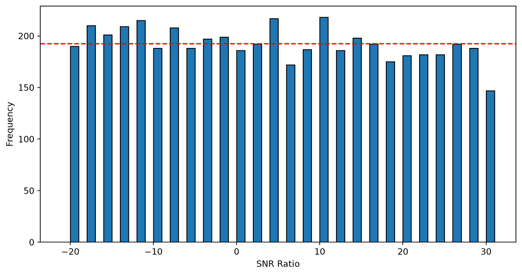

Figure 1: Distribution of Signal-to-Noise Ratio in the RadioML dataset

## Conclusion

- Tactical Electronic Warfare Takeaways
- Future Roadmap
1. **Adaptive ECCM Triggers:** When
   $$\sigma_{\text{epistemic}}$$
   spikes, the cognitive radio detects an anomalous, jammed RF state and triggers tactical frequency hopping.
2. **Robust Situational Awareness:** Provides pilots and autonomous drone swarms with actionable confidence intervals rather than misleading point estimates.
- Scale to the full 2.55-million frame RadioML benchmark via distributed variational inference.
- Evaluate out-of-distribution detection on specialized pulse and chirp jamming signatures.
- Deploy quantized BNN inference onto edge Software Defined Radios (Ettus USRP / FPGA).

**Final Thought**

*“In contested military operations, an estimate without uncertainty is a liability. Bayesian neural networks turn that liability into tactical awareness.”*

## References

Bai, Runbo, Xiumei Qiu, and Maosen Cao. 2009. “Factor Sensitivity Analysis for Multivariable Systems Using Bayesian Neural Networks.” *2009 International Conference on Computational Intelligence and Security* 1: 30–33. https://doi.org/10.1109/CIS.2009.43.

Bishop, Christopher M. 1997. “Bayesian Neural Networks.” *Journal of the Brazilian Computer Society* 4 (1). https://doi.org/10.1590/s0104-65001997000200006.

Snoek, Jasper, Oren Rippel, Kevin Swersky, et al. 2015. “Scalable Bayesian Optimization Using Deep Neural Networks.” *International Conference on Machine Learning*, 2171–80.